# Does a relationship exist?

Anthony

Oct 6 2023

**Directions**: You are encouraged to work together! Write your solutions in Rmarkdown and submit your solutions as a rendered HTML or PDF file. Only (sufficiently well done) HTML or PDF submissions will be counted as complete. Install packages in your R console and only load them in your markdown file. Installing packages in your markdown file will create an error.

1. Explain whether each of the statements below is a fact or a correlation? Justify your answer.
1. Most top performing schools have small student bodies.

### It is a fact.Because it does not have variation on both sides. We don’t know if poor performing schools have even smaller student bodies.

2. Married people are typically happier than unmarried people.

### It is a correlation. Because it tells that married people are happier and unmarried people are less happier. Variation on both sides are clear.

3. Among professionals, taller basketball players tend to have lower free-throw percentages than shorter players.

### It is a correlation. Because it tells that taller players have lower free-throw percentages and shorter players have higher free-throw percentages.Variation on both sides are clear.

4. The locations in the U.S. with the highest cancer rates are typically small towns.

### It is a fact. Because it talks about the locations with the highest cancer rates only. While locations with lower cancer rates can also be small towns. There is no variation on both sides.

5. Older houses are more likely to have lead paint than newer ones.

### It is a correlation. Because it tells us that older houses are more likely to have lead paint and newer ones are less likely to have lead paint. Variation on both sides are clear.

6. Most colds caught in Lane County are caught on cold days.

### It is a fact. First, there is no variation on both sides. Second, We cannot imply that less colds caught in hot days from this statement.

2. Comment on each of the graphs below. What does it tell us? What kind of graph is it? What is the x-axis? What is the y-axis? Is the graph misleading? Why? (Based on BW book)

Note: You do not need to include the figures in your responses so I have cut them from the template.

1. FRED graph ### It tells us the change in unemployement rate from 2000 to 2020. It is a line chart.

### The x-axis is year. Y-axis is percent of unemployement.

### It is misleading because it does not start from zero.

2. Covid Cases

### It tells us the weekly increase in cumulative ediatric COVID-19 Cases. It is a line chart.

### The x-axis is date and y-axis the percentage of increase.

### The graph is misleading because it should put the cummunative number of COIVD-19 cases on the y-axis.

c.Taxes

### It tells us the amount of total taxable income for taxpayer in different income ranges. This is a bar chart.

### The x-axis is income ranges. The y-axis is the amount of taxable income.

### This graph is misleading because the gap among each range of income varies from 5K to 5M.

4. Hours of Work

### It tells us the average number of actual weekly hours of work in main job. It is a bar chart.

### The x-axis is the number of hours worked. The y-axis is country.

### This graph is misleading because the x-axis should starts from zero.

e.Gun Deaths in Florida

### It tells us the number of murders committed using firearms over years. It is an area chart/line chart.

### The x-axis is year and the y-axis is number of murders

### This graph is misleading beacause it gets the y-axis reversed. 0 should startt at the bottom.

6. Ready for Retirement?

### It tells the change in the share of non-retired americans who feel their retirement savings plan is on track. It is a line chart.

### The x-axis is the years. The y-axis is the percentage.

### This graph is misleading. Because the y-axis does not start from 0.

3. In class, we used the National Longitudinal Survey of Youth 1979 to measure the correlation between income and years of education.

The data file `nlsy79.csv` includes this information and some additional variables we may use later in the course. A description of the variables in the data is in the table below.

| Name | Description |
| --- | --- |
| `CASEID` | Unique identifier |
| `earn2009` | Earnings in 2009 |
| `hgc` | Years of education |
| `race` | Race and Ethnicity |
| `sex` | Gender |
| `bmonth` | Birth Month |
| `byear` | Birth Year |
| `afqt` | Armed Forces Qualifying Test Percentile |
| `region_1979` | Region |
| `faminc1978` | Family Income in 1978 |
| `nsibs79` | Number of Siblings |

1. Re-code everyone who has 8 or fewer years of education as 8 in the data. We will interpret this category as “8 years or less”.

```r
# You can type your R code here.
library(readr)
library(dplyr)
nlsy79 <- read_csv('nlsy79.csv')

#Recode everyone who has 8 or fewer years of education as 8 in the data, including missing NA
nlsy79 <- nlsy79 %>%
  mutate(hgc = ifelse(is.na(hgc) | hgc <= 8, 8, hgc))
```

2. Use ggplot to make a bar chart showing the share of the sample with each level of education. What percentage of the population has 17 years of education or more?

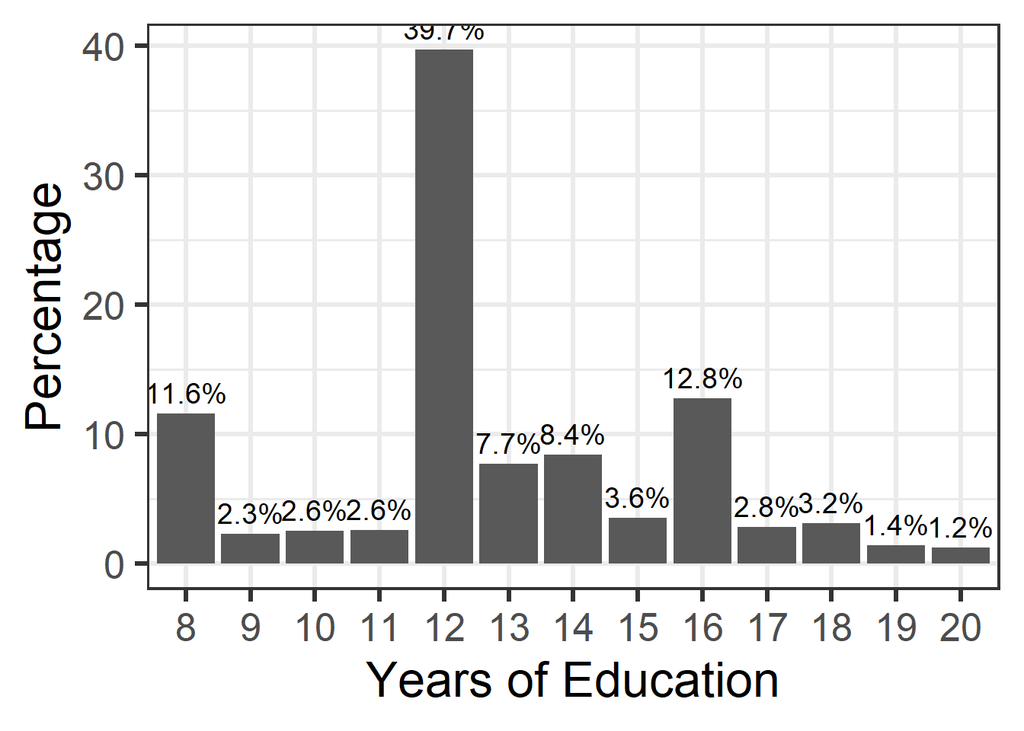

```r
library(ggplot2)

# Calculate the percentage of each education level
education_percentages <- nlsy79 %>%
  group_by(hgc) %>%
  summarise(percentage = n() / nrow(nlsy79) * 100)  # Calculate percentage

# Create a bar chart with percentages and data labels
ggplot(education_percentages, aes(x = factor(hgc), y = percentage)) +
  geom_bar(stat = "identity") +
  geom_text(aes(label = sprintf("%.1f%%", percentage)), vjust = -0.5, size = 5) +  # Add data labels
  xlab("Years of Education") +
  ylab("Percentage") +
  theme_bw(base_size = 24) +
  scale_x_discrete(labels = function(x) as.numeric(as.character(x)))  # Ensures x-axis labels are displayed as numbers
```

### The percentage of population that has 17 years of education or more is 2.8%+3.2%+1.4%+1.2%=8.6%

3. Use ggplot to make a scatterplot showing the relationship between earnings and education (recoded as in part a), include the line of best fit. What is the relationship between earnings and educcation?

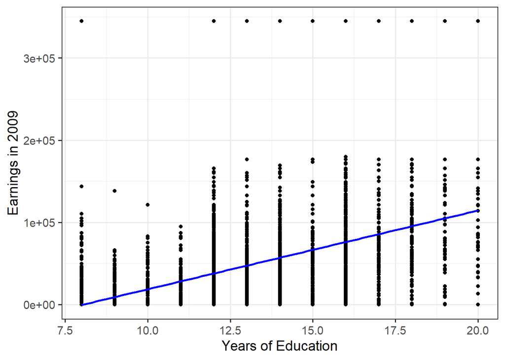

```r
# Create scatterplot with the line of best fit
ggplot(nlsy79, aes(x = hgc, y = earn2009)) +
  geom_point() +  # Add scatterplot points
  geom_smooth(method = 'lm', se = FALSE, color = 'blue') +  # Add line of best fit
  xlab("Years of Education") +
  ylab("Earnings in 2009") +
  theme_bw(base_size = 14)  # Adjust the base size of the theme as per your preference
```

### The relationship between earnings and education indicates a positive correlation between these two variables.

4. Use ggplot to make a figure showing the average earnings by years of education with the line of best fit. Comment on how well the line of best fit matches the average earnings data.

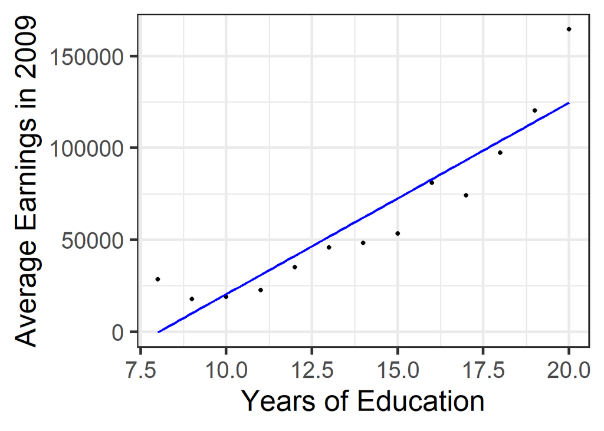

```r
# Calculate the average earnings by years of education
average_earnings <- nlsy79 %>%
  group_by(hgc) %>%
  summarize(avg_earnings = mean(earn2009, na.rm = TRUE))

# Create the plot with average earnings and the line of best fit
ggplot(average_earnings, aes(x = hgc, y = avg_earnings)) +
  geom_point() +                             # Add points for average earnings
  geom_smooth(method='lm', se=FALSE, color='blue') +  # Add the line of best fit
  xlab("Years of Education") +
  ylab("Average Earnings in 2009") +
  theme_bw(base_size = 24)
```